# Precipitation mapping using kriging techniques: Kriging prediction

# 1 Abstract

# 2 Objectives

# 3 Introduction

# 4 Kriging prediction

The kriging approach is a method for modeling and smoothing a set of stochastic observations and make predictions for new unobserved input locations (input values). The kriging approach bases the accurate generalization (prediction) of data on the correlation structure among the data. The correlation strucutre of the data is defined by the semivariogram function.

## 4.1 Mean and variance kriging prediction

Given a set of sample observations $\boldsymbol{y}= \{y(s_i)\}$ from a spatial stochastic process at the spatial locations $s_i$, with $i=1,\dots,n$ location indices. A kriging prediction of the stochastic process at a unobserved arbitrary spatial location $s_0$ is the lineal combination of the observed values at the sample locations:

$$\begin{align*}
\hat{y}(s_0)= \sum_{i=1}^n \lambda_i y(s_i),
\end{align*}$$

where the weights $\lambda_1,\dots,\lambda_n$ are those that minimize the mean squared error

$$\begin{align*}
E[(y(s_0) - \hat{y}(s_0)^2],
\end{align*}$$

under the constraint of $\sum_{i=1}^n \lambda_i=1$ that, jointly with the stationarity of the mean process, guarantees an unbiassed predictor. We can distinguish the simple kriging, or kriging without a global tendency, and the universal kriging, or kriging with a global tendency. In the simple kriging the mean of the process is considered as a constant function (null or constant global tendency). In the universal kriging the mean of the process is considered as a linear regression function of input values (global tendency function), such as:

$$\begin{align*}
\mu(s_i) = \beta_0 + \beta_1 x_1(s_i) + \cdots + \beta_p x_p(s_i) = \boldsymbol{\beta} \boldsymbol{x}(s_i),
\end{align*}$$

where $\boldsymbol{x}(s_i)=(1,x_1(s_i),\dots, x_p(s_i))^\top$ is the vector with the $p$ input values associated to spatial location $s_i$ and $\boldsymbol{\beta}=(\beta_0,\beta_1,\dots, \beta_p)$ is the vector with the linear coefficients.

The solution to this optimization problem is for the estimated mean, following Cressie (1993):

$$\begin{align*}
\hat{y}(s_0) = [\boldsymbol{\gamma} + X(X^\top \Gamma^{-1} X)(\boldsymbol{x}(s_0) - X^\top \Gamma^{-1} \boldsymbol{\gamma})]^\top \Gamma^{-1} \boldsymbol{y},
\end{align*}$$

and for the estimated variance:

$$\begin{align*}
\sigma^2_s = \boldsymbol{\gamma}^\top \Gamma^{-1} \boldsymbol{\gamma} - \frac{(\boldsymbol{I}^\top \Gamma^{-1} \boldsymbol{\gamma} - 1)^2}{\boldsymbol{I}^\top \Gamma^{-1} \boldsymbol{I}},
\end{align*}$$

where $X=[\boldsymbol{x}(s_1) \; \cdots \; \boldsymbol{x}(s_i) \; \cdots \; \boldsymbol{x}(s_n)]^\top \in \mathbb{R}^{n \times p}$ is the matrix with the $p$ input values for the $n$ sample observations and $\boldsymbol{x}(s_0)=(x_1(s_0),\dots,x_p(s_0))^\top$ is the vector with the $p$ input values for the location $s_0$. In the vector $\boldsymbol{\gamma}=(\gamma(|s_1-s_0|),\dots,\gamma(|s_n-s_0|))^\top$ and matrix $\Gamma \in \mathbb{R}^{n\times n}$ with element $\Gamma_{(i,j)}=\gamma(|s_i-s_j|)$, $\gamma$ represents the semivariogram function as a function of the euclidean distance between the sample locations $s_i$ and $s_j$ ($i,j=1,\dots,n$).

## 4.2 Semivariogram function

The spatial semivariogram function $\gamma$ defines the correlation structure among observed values of a stationary stochastic process, determining the relationships between the observations at different spatial locations. A stochastic process is said to be stationary when the covariance between two observations is a function of the difference of spatial locations:

$$\begin{align*}
\mathrm{cov}(y(s_i),y(s_j)) = f(s_i - s_j),
\end{align*}$$

and isotropic when is a function of the norm between two spatial locations:

$$\begin{align*}
\mathrm{cov}(y(s_i),y(s_j)) = f(|s_i - s_j|) = f(h),
\end{align*}$$

with $h=|s_i - s_j|$. A stationary and isotropic spatial semivariogram funcion is the semivariance of the increments of the observations of the stochastic process:

$$\begin{align*}
\gamma(h)=\frac{1}{2} \mathrm{var}(y(s + h) - y(s)), \tag{4.1}
\end{align*}$$

where $s$ represents an arbitrary spatial location and $h$ the spatial distance between two arbitrary spatial locations.

From classical geostatistics the semivariogram needs to be estimated beforehand from the sample observations. The first step is to obtain the empirical semivariogram, and secondly to adjust an analytical function for the semivariogram function over the empirical variogram.

### 4.2.1 Empirical semivariogram

The empirical variagram consists in computing the semivariances, according the equation (4.1), for the different spatial distances $h > 0$ among spatial locations, as follows:

$$\begin{align*}
\gamma(h)=\frac{1}{2} \frac{1}{||N(h)||} \sum_{i,j \in N(h)}(y(s_i) - y(s_j)),
\end{align*}$$

### 4.2.2 Semivariogram function

The empirical semivariogram provides a set of estimation values of the semivariogram function $\gamma(\cdot)$ for some distances. With this information, an analytical function for the semivariogram must be obtained. A valid semivariogram function must meet the following restrictions: $\gamma(0) \geq 0$, $\gamma(h) \leq \sigma^2$, $\forall h \geq 0$, where $\sigma^2$ is the variance of a single observation $\mathrm{var}(y(s_i))=\sigma^2$, $\forall s_i$, and be conditionally negative definite that ensures that the variance of a predicted value is non-negative .

Some of the most common families of parametric functions which ensure the property of conditionally negative definite for the semivariogram $\gamma(\cdot)$ are the following:

$$\begin{align*}
\text{Pure nugget effect:} & \hspace{1cm} \gamma(h) = \tau^2, \hspace{5mm} \forall h > 0 \\[2mm]
\text{Funcion exponencial:} & \hspace{1cm} \gamma(h) = \tau^2 + (\sigma^2 − \tau^2)\left(1-e^{-3\frac{h}{\phi}}\right), \hspace{5mm} \forall h > 0 \\[2mm]
\text{Funcion gaussiana:} & \hspace{1cm} \gamma(h) = \tau^2 + (\sigma^2 − \tau^2)\left(1-e^{-3(\frac{h}{\phi})^2}\right), \hspace{5mm} \forall h > 0 \\[2mm]
\text{Funcion esferica:} & \hspace{1cm} \gamma(h) = \left\{ \begin{array}{cc}
\tau^2 + (\sigma^2 − \tau^2)\left( \frac{3h}{2\phi} - \frac{h^3}{2\phi^3}\right),& \hspace{5mm} 0 < h > 0\\
\sigma^2,& \hspace{5mm} h \geq \phi\\
\end{array} \right.\\[2mm]
\text{Funcion Matern:} & \hspace{1cm} \gamma_\kappa(h) = \tau^2 + (\sigma^2 − \tau^2)\left(1- \frac{(2\sqrt{\kappa} h / \phi)^\kappa}{2^{\kappa-1} \Gamma(\kappa)} K_\kappa \left(\frac{2\sqrt{\kappa}h}{\phi}\right) \right), \hspace{5mm} \forall \tau > 0,\\ & \hspace{1cm} \text{donde}\; K_\kappa\; \text{es la función Bessel modeificada de orden}\; \kappa.
\end{align*}$$

The Mat'ern family (Matérn 1986) is the most commonly used class of semivariogram functions, where the parameter $\kappa$ is the order of the function and controls the roughnesss of the process. More information about the Mat'ern family can be found in Handcock and Stein (1993), and in general about semivariogram functions in Diggle and Ribeiro (2007).

In the previous functions, $\tau^2 > 0$ represents the semivariance between observations when $h \rightarrow 0$, commonly known as nugget effect, and it can be the consequence of a discontinuity in the process, or of error in the measurements, or of both simultaneously:

$$\begin{align*}
\gamma(0)=\tau^2.
\end{align*}$$

In certain applications, might not be a nugget effect, then:

$$\begin{align*}
\gamma(0)= 0.
\end{align*}$$

The correlation between pairs of observations separated by large distances eventually disappears, which implies that their semivariance is equal to $\sigma^2$, which is indeed the variance of an observation:

$$\begin{align*}
\underset{h \rightarrow \infty}{\mathrm{lim}} \gamma(h)= \sigma^2.
\end{align*}$$

That $\sigma^2$ is known as the sill of the semivariogram.

The semivariogram can reach the sill for a certain distance $h$, which represents the distance where the correlation disappears, or it can asymptotically approach the sill. In the previous semivariogram family functions, the parameter $\phi$ represents the distance where the semivariance reaches 95% of the sill and is called the affective range. This parameter $\phi$ represents the rate of decay of the correlation as a function of the distance, which controls the smoothness or wigglyness of the spatial variability of the predictions. The larger the effective range $\phi$, the higher the spatial correlation and, therefore, the smoother the spatial variability of the predictions (smoother predictive functions). On the other hand, the smaller the $\phi$, the lower the spatial correlation and, therefore, the more wiggly the spatial variability of the predictions (more wiggly predictive functions).

Figure 4.1 shows a standard model for the semivariogram and the covariogram jointly with their characteristic parameters: nugget ($\tau^2$), sill ($\sigma^2$) and effective range ($\phi$). And Figure 4.2 shows schematically the most common families for the semivariogram functions written above. (Muñoz Viera 2012)

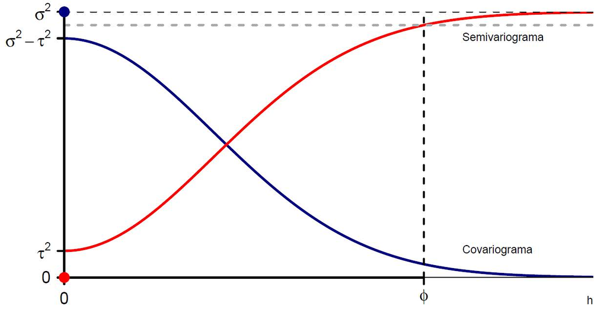

Figure 4.1: Standard models for the semivariogram and covariogram and their characteristic parameters. *Source: Muñoz Viera 2012

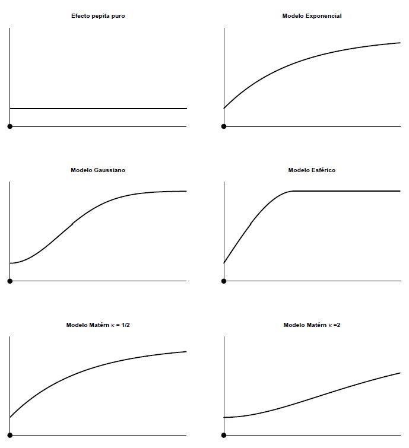

Figure 4.2: Models for the semivariogram. *Source: Muñoz Viera 2012

The estimation of the characteristic parameters of the semivariogram function from the sample data can be carried out by using standard optimization methods for functions, such as least square, generalized least square or maximun likelihood (Cressie and Hawkins 1980; Kitanidis 1983).

# 5 Methodology

## 5.1 Preliminaries

### 5.1.1 Install R-packages

Install packages in case you do not have them (or some of them) already installed in your computer.

```r
 #install.packages("maptools")
 #install.packages("rgdal")
 #install.packages("raster")
 #install.packages("classInt")
 #install.packages("RColorBrewer")
 #install.packages("latex2exp")
 #install.packages("formatR")
 #install.packages("knitr")
 #install.packages("geoR")
 #install.packages("rgeos")
```

### 5.1.2 Load R-packages

Load packages in your actual R session.

```r
library(maptools)
library(rgdal)
library(raster)
library(classInt)
library(RColorBrewer)
library(latex2exp)
library(formatR)
library(knitr)
library(geoR)
library(rgeos)
library(fields)
```

### 5.1.3 Set working directory

The present document is a R Markdown script document (Xie, Allaire, and Grolemund 2018), so the best way to set the current directory is via the command *opts_knit* (*help(opts_knit)*). In base R script documents the standard way to set the current directory is via the command *setwd*.

```r
opts_knit$set(root.dir = "C:/GABRIEL_20192301/Docencia_FPI/GEOESTADISTICA")
# setwd("C:/GEOESTADISTICA")
```

(Note that R uses forward slashes / in paths, while Windows uses backward slashes.)

## 5.2 Study area

The study area corresponds to the Valencian Community (CV), Spain, and its surroundings, which is a Mediterranean coastal zone located in eastern Spain with an area of 23,255 Km2. It contains a mountainous area where the highest altitudes are about 1800 m. There exists a littoral plain region, principally constituted by floodplains and alluvial fans, and a coastline formed by smooth beaches and coastal lagoons.

### 5.2.1 Borders of the Valencian Community

The boundaries of the CV are provided by the shape file *cv*, and by using the R command *readOGR* it can be converted to the spatial-polygons R-object *lim_cv* (Bivand et al. 2008).

```r
getwd()
lim_cv <- readOGR(dsn="Datos_cp4", layer="cv")
```

For more details about the structure and content of this spatial-polygons R-object *lim_cv* see the R-notebook ‘Precipitation mapping using kriging techniques: Descriptive analysis and linear regression’.

## 5.3 Data set

### 5.3.1 Elevation map

A elevation map of the CV and its surroundings is provided by a raster file, and by means of the R command *raster* it is converted to the raster R-object *ras*.

```r
ras <- raster("Datos_cp4/mde_100.tif", values=TRUE)
```

For more details about the structure and content of this raster R-object *ras* see the R-notebook ‘Precipitation mapping using kriging techniques: Descriptive analysis and linear regression’.

### 5.3.2 Observational precipitation variables and input variables

The observational data set consists in precipitation observations and associated attributes of the observed locations as the spatial coordinates and the elevation. Thus, data set contains mean precipitation data for the period of 1960-2005 in 212 meteorological stations of the CV. Our study considers seasonal temporal scales. Thus, monthly rainfall means were grouped into the following variables: *spring* (spring: March, April, May), *summer* (summer: June, July, August), *autumn* (autumn: September, October, November), and *winter* (winter: December, January, February). *annual* contains the mean annual precipitation in each meteorological observatory.

The precipitation variables as well as the spatial coordinates and the elevation of the observed points are provided by a shape file. The spatial coordinates and the elevation are considered the input variables. The points shape file *precip_seasonal* which contains these data is read and converted to the spatial-points R-object *dat* by using the command *readOGR*.

```r
dat <- readOGR(dsn="Datos_cp4", layer="precip_seasonal", integer64="warn.loss")
str(dat)
```

[output not shown]

For more details about the structure and content of this spatial-points R-object *dat* as well as the histograms and descriptive statistics of the precipitation and input variables see the R-notebook ‘Precipitation mapping using kriging techniques: Descriptive analysis and linear regression’.

In Figure 5.1 the spring precipitation at the observed loactions, the elevation map of the CV and the borders of the CV are mapped.

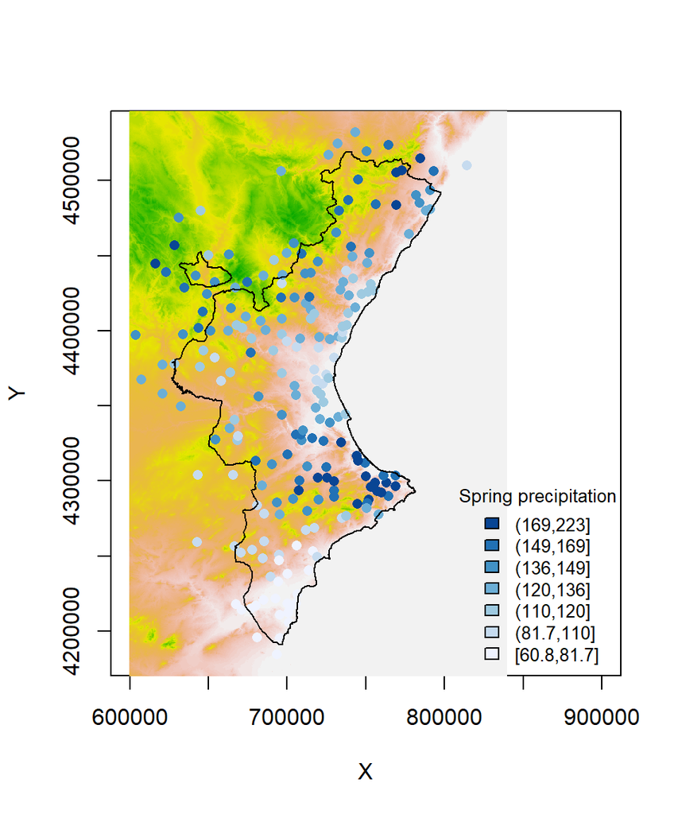

```r
# plot settings (see help(par))
# par(mfrow=c(1,2), mar=c(3.7, 4.1, 2.1, 1.1), mgp=c(1.8,0.6,0))

plot(dat@coords[ ,1:2], type="n", xlim=c(600000,900000), xlab="X", ylab="Y") # plot frame

image(ras, add=TRUE, col=terrain.colors(70, alpha=1)[70:1]) # adding the altitude map

# plotting the spring precipitation observations
q1 <- quantile(dat@data$spring, c(0,0.10,0.25,0.40,0.60,0.75,0.90,1))
br1 <- cut(dat@data$spring, breaks=q1, include.lowest=TRUE)
points(dat@coords[ ,1:2], type="p", col=brewer.pal(7,"Blues")[1:7][br1], asp=1, pch=16)

plot(lim_cv, add=TRUE) # adding the CV limits

# adding a legend for the spring observations
legend("bottomright", legend=levels(br1)[7:1], fill=brewer.pal(7,"Blues")[7:1], title= "Spring precipitation", cex=0.8, box.col = "grey", xpd = NA, bty = "n")
```

### 5.3.3 Grid of predicting locations and predicting input variables

In order to obtain a continuous map of precipitation, we need to make punctual predictions in a dense grid of locations and have the input variables for these predicting locations. In R there are different ways to define a grid. In this case, we are going to use the raster R-object *ras* of the elvation map above obtained to construct the grid of predicting locations. The collection of pixel mid points make a grid itself, so we just have to extract the mid points and their *x* and *y* spatial coordinates of every pixel. As the raster R-object *ras* contains the elevation values of every location, then we directly have the three input variables needed: *altitud* and the spatial coordinates *x* and *y*.

In order to save computation, the spatial resolution of the raster object can be reduced, thus the number of points of the resulting grid will not be so large and further computation reduced. The command *aggregate* can be used for this pourpose, specifying a reduction factor. In this case we use a reduction factor of 1/16 (*fact=c(4,4)*).

```r
ras <- aggregate(ras, fact=c(4,4), fun=mean)
```

Then, using the command *rasterToPoints*, the raster object *ras* can be converted to the SpatialPoints object *loc* and thus obtaning the grid of predicting locations, which already has the three input variables: *altitud* and the spatial coordinates *x* and *y*. The variable *mde_100* in the slot *data* contains the altitud values of every location. The slot *coords* is a two-column matrix which also contains the two spatial coordinates *x* and *Y* of every locations.

```r
loc <- rasterToPoints(ras, fun=NULL, spatial=TRUE)
str(loc)
```

```
## Formal class 'SpatialPointsDataFrame' [package "sp"] with 5 slots
##   ..@ data       :'data.frame':  601601 obs. of  1 variable:
##   .. ..$ mde_100: num [1:601601] 805 794 774 743 765 ...
##   ..@ coords.nrs : num(0)
##   ..@ coords     : num [1:601601, 1:2] 599839 600239 600639 601039 601439 ...
##   .. ..- attr(*, "dimnames")=List of 2
##   .. .. ..$ : NULL
##   .. .. ..$ : chr [1:2] "x" "y"
##   ..@ bbox       : num [1:2, 1:2] 599839 4149746 839839 4549746
##   .. ..- attr(*, "dimnames")=List of 2
##   .. .. ..$ : chr [1:2] "x" "y"
##   .. .. ..$ : chr [1:2] "min" "max"
##   ..@ proj4string:Formal class 'CRS' [package "sp"] with 1 slot
##   .. .. ..@ projargs: chr "+proj=utm +zone=30 +ellps=GRS80 +units=m +no_defs"
```

Finally, the grid of predicting locations *loc* can be restricted to the study area by clipping it by the borders of CV. The command *crop* can be used for this purpose.

```r
loc <- crop(loc, lim_cv)
```

## 5.4 Isotropic (omnidirectional) semivariogram with global tendency.

### 5.4.1 Scale and center the spatial coordinates

Using the library ‘geoR’ to peformm kriging, a numerical inestability error is obtained when data have UTM spatial coordinates. Therefore, we have to make the computations, the semivariogram and the kriging predictions, using scaled spatial coordinates.

```r
media <- colMeans(loc@coords[,]) # Centroid of the object 'loc'
desv <- sd(loc@coords[,]) # Common standard deviation of X and Y coordinates.
```

Scaling the observations

```r
dat@coords <- scale(dat@coords, center= media, scale= c(desv,desv))
```

Scaling the predicting locations

```r
loc@coords <- scale(loc@coords, center= media, scale= c(desv,desv))
```

### 5.4.2 Semivariogram for the whole spatial distance domain.

#### 5.4.2.1 Histogram of pair-wise distances in each interval

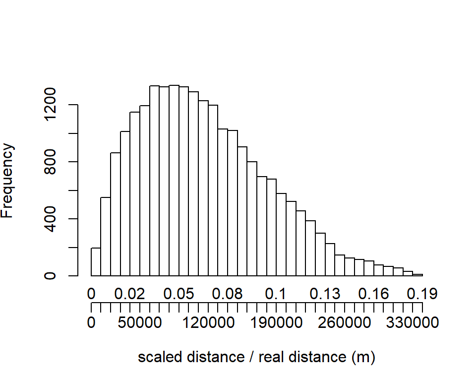

```r
distancias <- as.matrix(dist(dat@coords))[upper.tri(as.matrix(dist(dat@coords)), diag=FALSE)]

hist(distancias[distancias<=340000/desv], breaks=seq(0,340000,10000)/desv, main="", xlab="scaled distance / real distance (m)", xaxt="n", mgp=c(3.3, 1, 0))

axis(1, at= seq(0,340000,10000)/desv, labels= round(seq(0,340000,10000)/desv,2), tick= TRUE, mgp=c(3, 0, 1))
axis(1, at= seq(0,340000,10000)/desv, labels= round(seq(0,340000,10000)), tick= FALSE, mgp=c(3, 1.5, 0))
```

#### 5.4.2.2 Empiric semivariogram for the whole spatial distance domain.

```r
svar2 <- variog(coords=dat@coords, data=dat@data$spring, trend= ~dat@coords[,1]*dat@coords[,2]*dat@data$ALTITUD, breaks=seq(0,340000,10000)/desv)
```

```
## variog: computing omnidirectional variogram
```

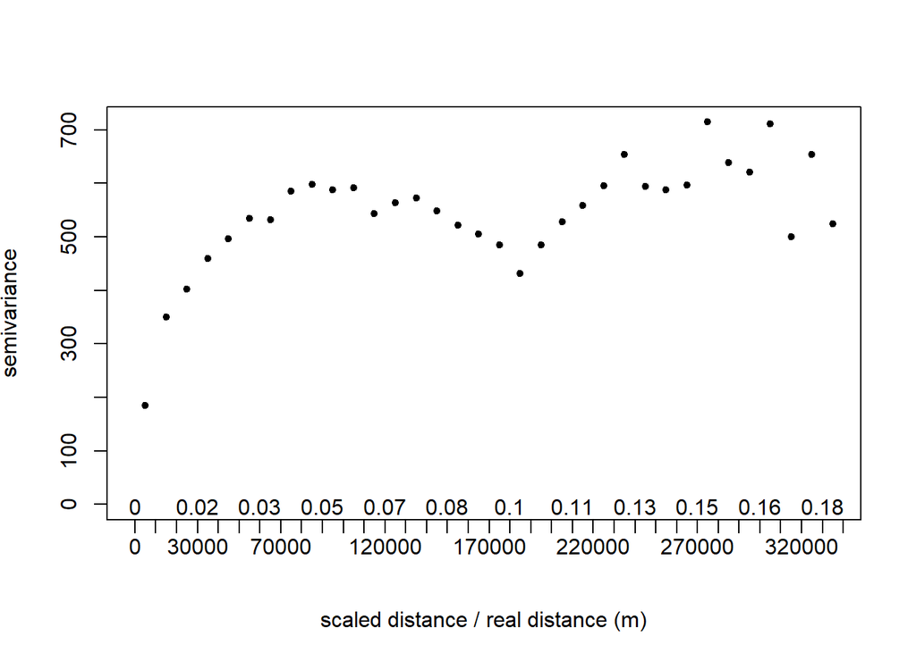

```r
plot(svar2, pch=20, cex=1, xlab="scaled distance / real distance (m)", xaxt="n", mgp=c(3.3, 1, 0))

axis(1, at= seq(0,340000,10000)/desv, labels= round(seq(0,340000,10000)/desv,2), tick= TRUE, mgp=c(3, -1, 0))
axis(1, at= seq(0,340000,10000)/desv, labels= round(seq(0,340000,10000)), tick= TRUE, mgp=c(3, 0.5, 0))
```

### 5.4.3 Semivariogram for a shorter spatial distance domain.

#### 5.4.3.1 Histogram of pair-wise distances in each interval

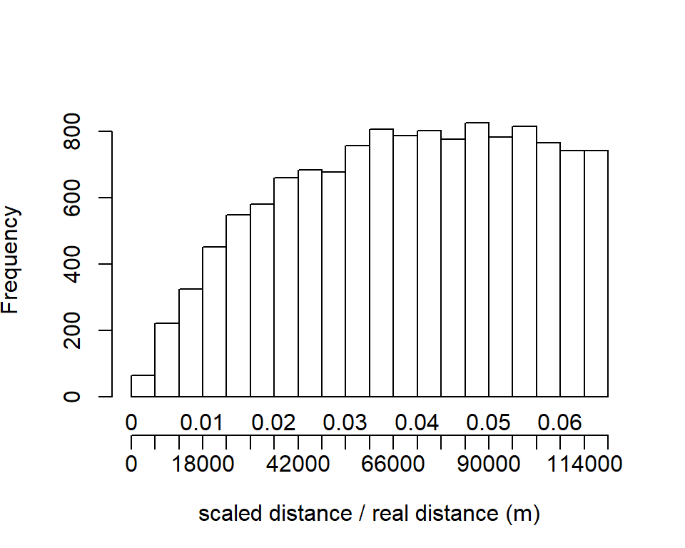

```r
distancias <- as.matrix(dist(dat@coords))[upper.tri(as.matrix(dist(dat@coords)), diag=FALSE)]

hist(distancias[distancias<=120000/desv], breaks=seq(0,120000,6000)/desv, main="", xlab="scaled distance / real distance (m)", xaxt="n", mgp=c(3.3, 1, 0))

axis(1, at= seq(0,120000,6000)/desv, labels= round(seq(0,120000,6000)/desv,2), tick= TRUE, mgp=c(3, 0, 1))
axis(1, at= seq(0,120000,6000)/desv, labels= round(seq(0,120000,6000)), tick= TRUE, mgp=c(3, 1.5, 1))
```

#### 5.4.3.2 Empiric semivariogram.

```r
svar2 <- variog(coords=dat@coords, data=dat@data$spring, max.dist=150000/desv, trend= ~dat@coords[,1]*dat@coords[,2]*dat@data$ALTITUD, breaks=seq(0,150000,6000)/desv)
```

```
## variog: computing omnidirectional variogram
```

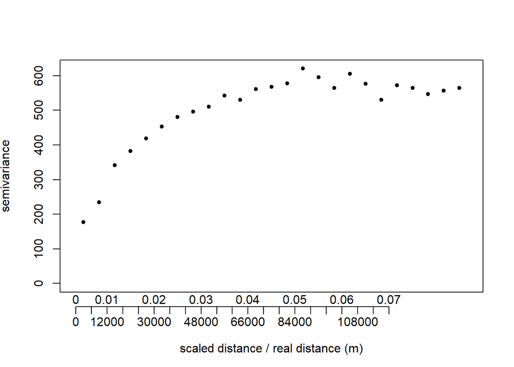

```r
plot(svar2, pch=20, cex=1, xlab="scaled distance / real distance (m)", xaxt="n", mgp=c(3.3, 1, 0), xlim=c(0,150000)/desv)

axis(1, at= seq(0,120000,6000)/desv, labels= round(seq(0,120000,6000)/desv,2), tick= TRUE, mgp=c(3, 0, 1))
axis(1, at= seq(0,120000,6000)/desv, labels= round(seq(0,120000,6000)), tick= TRUE, mgp=c(3, 1.5, 1))
```

#### 5.4.3.3 Semivariogram function.

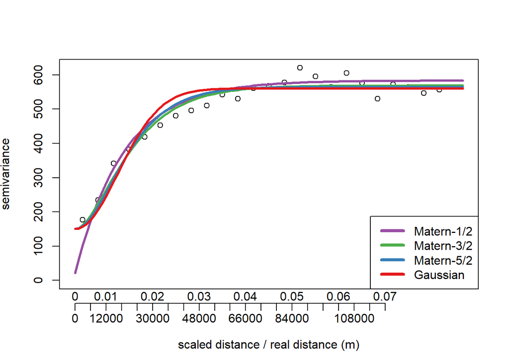

```r
sill <- 600
range <- 100000/desv

plot(svar2, xlab="scaled distance / real distance (m)", xaxt="n", mgp=c(3.3, 1, 0), xlim=c(0,150000)/desv)

svar.mat12 <- variofit(vario=svar2, ini=c(sill, range), cov.model='matern', fix.nugget=FALSE, nugget=130, fix.kappa=TRUE, kappa=0.5, weights='cressie', minimisation.function='optim')
lines(svar.mat12, lwd=3, col=brewer.pal(4,"Set1")[4])

svar.mat32 <- variofit(vario=svar2, ini=c(sill, range), cov.model='matern', fix.nugget=TRUE, nugget=150, fix.kappa=TRUE, kappa=1.5, weights='cressie', minimisation.function='optim')
lines(svar.mat32, lwd=3, col=brewer.pal(4,"Set1")[3])

svar.mat52 <- variofit(vario=svar2, ini=c(sill, range), cov.model='matern', fix.nugget=TRUE, nugget=150, fix.kappa=TRUE, kappa=2.5, weights='cressie', minimisation.function='optim')
lines(svar.mat52, lwd=3, col=brewer.pal(4,"Set1")[2])

svar.gau <- variofit(vario=svar2, ini=c(sill, range), cov.model='gaussian', fix.nugget=TRUE, nugget=150, weights='cressie', minimisation.function='optim')
lines(svar.gau, lwd=3, col=brewer.pal(4,"Set1")[1])

legend("bottomright", legend= c("Matern-1/2","Matern-3/2","Matern-5/2","Gaussian"), col = brewer.pal(4,"Set1")[4:1], lty= 1, cex=1, lwd=4)

axis(1, at= seq(0,120000,6000)/desv, labels= round(seq(0,120000,6000)/desv,2), tick= TRUE, mgp=c(3, 0, 1))
axis(1, at= seq(0,120000,6000)/desv, labels= round(seq(0,120000,6000)), tick= TRUE, mgp=c(3, 1.5, 1))
```

## 5.5 Kriging prediction

### 5.5.1 Kriging prediction

Adjustment of Kriging model

```r
uk <- krige.conv(data=dat@data$spring, coords=dat@coords, locations= loc@coords, krige= krige.control(type.krige = "ok", trend.d= trend.spatial( ~dat@coords[,1]*dat@coords[,2]*dat@data$ALTITUD ), trend.l= trend.spatial( ~loc@coords[,1]*loc@coords[,2]*loc@data$mde_100 ), obj.model= svar.mat32))
```

```
## krige.conv: model with covariates matrix provided by the user
## krige.conv: Kriging performed using global neighbourhood
```

```r
str(uk)
```

```
## List of 6
##  $ predict     : num [1:145434] 138 140 141 141 139 ...
##  $ krige.var   : num [1:145434] 261 267 271 269 265 ...
##  $ beta.est    : Named num [1:8] 1.09e+02 6.22e+02 1.79e+02 4.25e-02 -6.93e+03 ...
##   ..- attr(*, "names")= chr [1:8] "beta0" "beta1" "beta2" "beta3" ...
##  $ distribution: chr "normal"
##  $ message     : chr "krige.conv: Kriging performed using global neighbourhood"
##  $ call        : language krige.conv(coords = dat@coords, data = dat@data$spring, locations = loc@coords,      krige = krige.control(type.k| __truncated__ ...
##  - attr(*, "sp.dim")= chr "2d"
##  - attr(*, "prediction.locations")= language loc@coords
##  - attr(*, "parent.env")=<environment: R_GlobalEnv>
##  - attr(*, "data.locations")= language dat@coords
##  - attr(*, "class")= chr "kriging"
```

Adding kriging outcomes to the object ‘loc’

```r
loc@data$predict <- uk$predict  # predictions
loc@data$predict.sd <- sqrt(uk$krige.var)  # prediction error
```

### 5.5.2 Cross-validation (CV) model assesment

```r
for(i in 1:212){
uk_vc <- krige.conv(data= dat@data$spring[-i], coords= dat@coords[-i,], locations= dat@coords[i,], borders= NULL, krige= krige.control(type.krige= "ok", trend.d= trend.spatial( ~dat@coords[-i,1]*dat@coords[-i,2]*dat@data$ALTITUD[-i]), trend.l= trend.spatial( ~dat@coords[i,1]*dat@coords[i,2]*dat@data$ALTITUD[i]), obj.model= svar.mat32))

dat@data$predict.cv[i] <- uk_vc$predict
dat@data$predict.cv.sd[i] <- sqrt(uk_vc$krige.var)
}
```

Computing Cross-validation (CV) residuals

```r
dat@data$res.cv <- dat@data$spring[] - dat@data$predict.cv
summary(dat@data$res.cv)
```

```
##     Min.  1st Qu.   Median     Mean  3rd Qu.     Max.
## -50.1352  -7.7594  -0.6889  -0.2026   7.0716  47.9620
```

Diagnosis plots

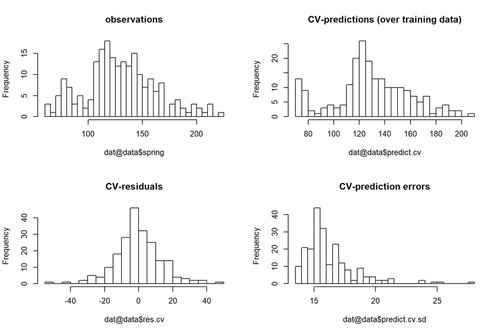

```r
# Histogram of the cross-validation
par(mfrow=c(2,2))
hist(dat@data$spring, breaks=30, main="observations")
hist(dat@data$predict.cv, breaks=30, main="CV-predictions (over training data)")
hist(dat@data$res.cv, breaks=30, main="CV-residuals")
hist(dat@data$predict.cv.sd, breaks=30, main="CV-prediction errors")
```

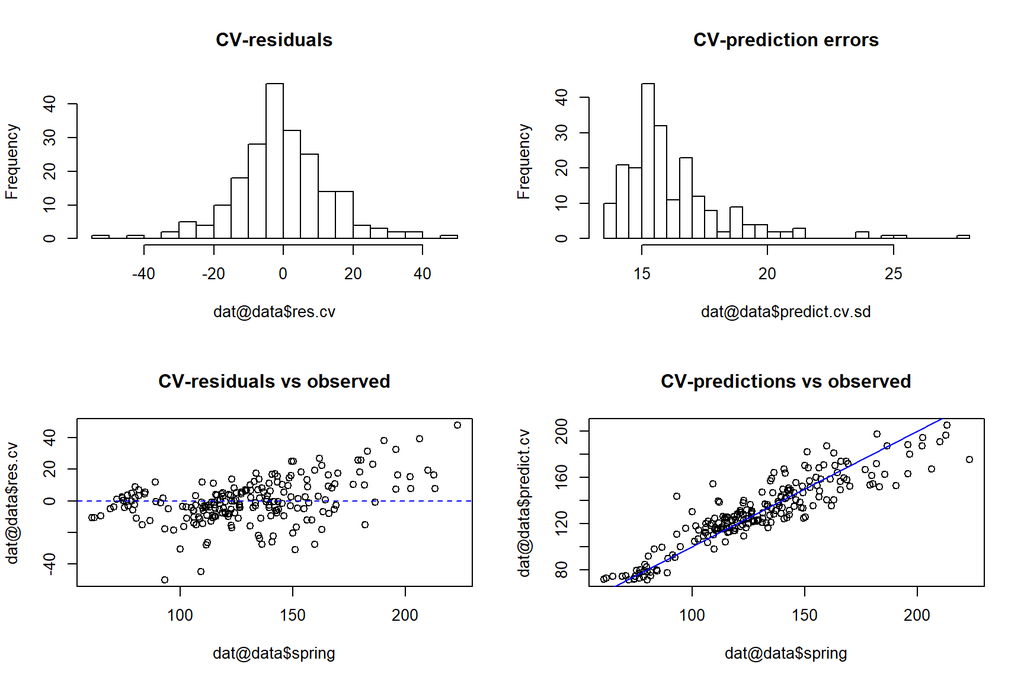

```r
# Diagnosis plots
par(mfrow=c(2,2))
hist(dat@data$res.cv, breaks=30, main="CV-residuals")
hist(dat@data$predict.cv.sd, breaks=30, main="CV-prediction errors")
plot(dat@data$spring, dat@data$res.cv, main="CV-residuals vs observed")
abline(h=0, col="blue", lty=2)
plot(dat@data$spring, dat@data$predict.cv, main="CV-predictions vs observed")
abline(a=0, b=1, col="blue", lty=1, lwd=1)
```

Identifying outliers

```r
dat@data[ dat@data$res.cv < -40 | dat@data$res.cv > 40 , c(1:2,12:19)]
```

```
##     INDICATIU               ESTACIO spring summer autumn winter annual
## 44     E8039A    TARBENA  C H JUCAR 223.14  49.58 269.07 273.81 815.60
## 173    E8472E              BARRACAS  93.26  47.73 102.74  72.93 316.67
## 212    E9987O AMPOSTA 'ERMS SALATS' 109.35  75.14 200.77 109.39 494.65
##     predict.cv predict.cv.sd    res.cv
## 44    175.1780      15.98194  47.96204
## 173   143.3952      15.21351 -50.13525
## 212   154.1510      27.98520 -44.80103
```

## 5.6 Map of the kriging predictions

### 5.6.1 Undo the scaling of the spatial coordinates

```r
loc@coords <- scale(loc@coords, center=FALSE, scale= 1/c(desv,desv))
loc@coords <- scale(loc@coords, center= -1*media, scale=FALSE)

dat@coords <- scale(dat@coords, center=FALSE, scale= 1/c(desv,desv))
dat@coords <- scale(dat@coords, center= -1*media, scale=FALSE)
```

### 5.6.2 Map of the kriging predictions

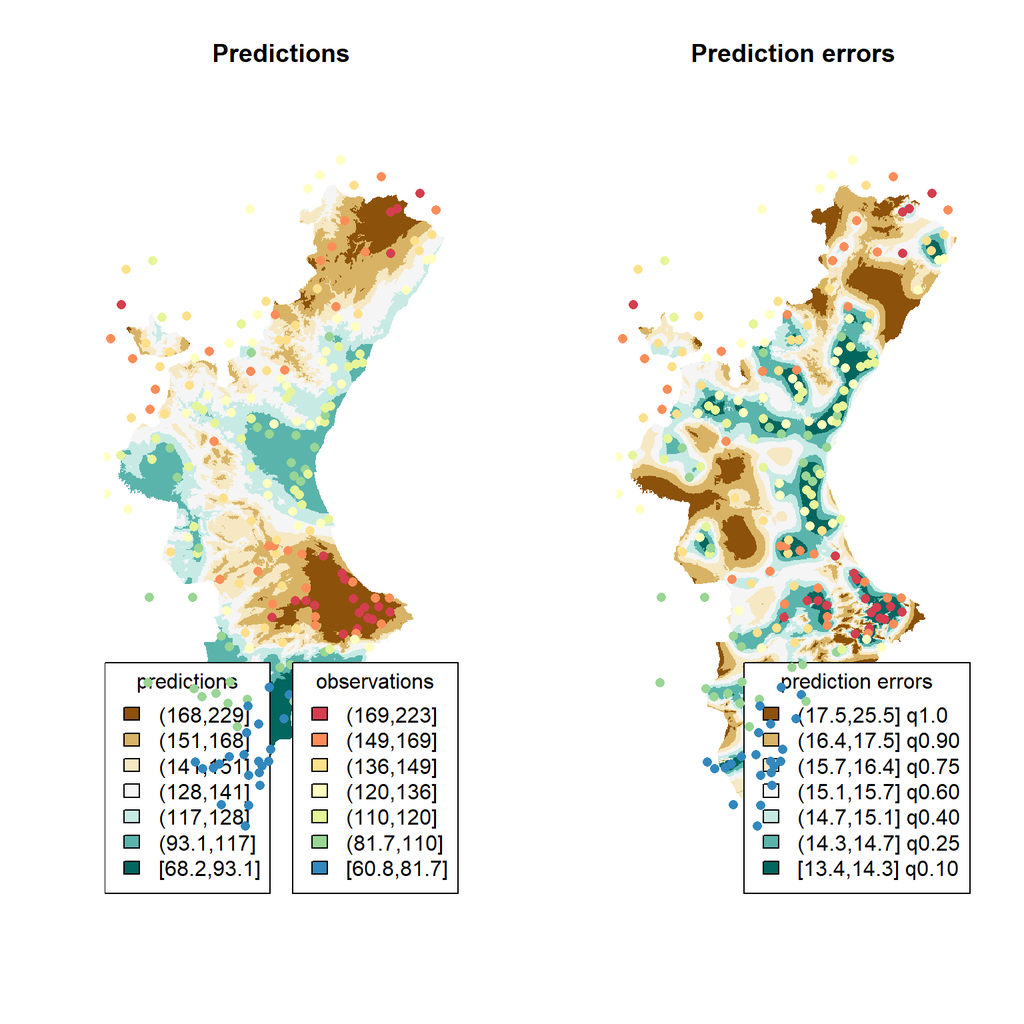

```r
par(mfrow=c(1,2))

# Predictions.
loc1_predict <- SpatialPixelsDataFrame(loc@coords, data=as.data.frame(loc@data$predict))

q2 <- quantile(loc1_predict@data[,1], c(0,0.10,0.25,0.40,0.60,0.75,0.90,1))
image(loc1_predict, col=brewer.pal(7,"BrBG")[7:1], asp=1, breaks=q2, main="Predictions")

# Legend.
br2 <- cut(loc1_predict@data[,1], breaks=q2, include.lowest=TRUE)
legend("bottomleft", legend=levels(br2)[7:1], fill=brewer.pal(7,"BrBG")[1:7], title= "predictions", cex=1)

# Observed data.
q3 <- quantile(dat@data$spring[], c(0,0.10,0.25,0.40,0.60,0.75,0.90,1))
br3 <- cut(dat@data$spring[], breaks=q3, include.lowest=TRUE)
points(dat@coords[,1], dat@coords[,2], col=brewer.pal(7,"Spectral")[7:1][br3], asp=1, pch=16)
legend("bottomright", legend=levels(br3)[7:1], fill=brewer.pal(7,"Spectral")[1:7], title= "observations", cex=1)


# Predicting errors.
loc1_predict.sd <- SpatialPixelsDataFrame(loc@coords, data=as.data.frame(loc@data$predict.sd))

q4 <- quantile(loc1_predict.sd@data[,1], c(0,0.10,0.25,0.40,0.60,0.75,0.90,1))
image(loc1_predict.sd, col=brewer.pal(7,"BrBG")[7:1], asp=1, breaks=q4, main="Prediction errors")

# Legend.
br4 <- cut(loc1_predict.sd@data[,1], breaks=q4, include.lowest=TRUE)
legend("bottomright", legend=paste(levels(br4)[7:1],c("q0.10","q0.25","q0.40","q0.60","q0.75","q0.90","q1.0")[7:1]), fill=brewer.pal(7,"BrBG")[1:7], title= "prediction errors", cex=1)

# Observed data.
points(dat@coords[,1], dat@coords[,2], col=brewer.pal(7,"Spectral")[7:1][br3], asp=1, pch=16)
```

# 6 Assignment

# 7 Conclussion

# 8 R-notebook

# References

Bivand, Roger S, Edzer J Pebesma, Virgilio Gómez-Rubio, and Edzer Jan Pebesma. 2008. *Applied Spatial Data Analysis with R*. Vol. 747248717. Springer.

Cressie, Noel. 1993. *Statistics for Spatial Data*. New York. Wiley-Interscience.

Cressie, Noel, and Douglas M Hawkins. 1980. “Robust Estimation of the Variogram: I.” *Journal of the International Association for Mathematical Geology* 12 (2): 115–25.

Diggle, PJ, and Paulo Justiniano Ribeiro. 2007. “Model-Based Geostatistics (Springer Series in Statistics).”

Handcock, Mark S, and Michael L Stein. 1993. “A Bayesian Analysis of Kriging.” *Technometrics* 35 (4): 403–10.

Kitanidis, Peter K. 1983. “Statistical Estimation of Polynomial Generalized Covariance Functions and Hydrologic Applications.” *Water Resources Research* 19 (4): 909–21.

Matérn, B. 1986. “Spatial Variation. Springer-Verlag.” *New York*.

Muñoz Viera, Facundo Martı́n. 2012. “Geoestadı́stica En Regiones Heterogéneas Con Distancia Basada En El Coste.” PhD thesis, Faculty of Mathematics, Universitat de València.

Xie, Yihui, Joseph J Allaire, and Garrett Grolemund. 2018. *R Markdown: The Definitive Guide*. CRC Press.